# Risk Factor Analysis

## Outcome Variable

**Outcome Variable:** ever_co

## Predictor Variables

**Intervention Variable:** predfeed3

**Adjustment Set:**

- arm
- sex
- month
- brthmon
- W_mage
- meducyrs
- feducyrs
- hhwealth_quart
- hfoodsec
- W_mhtcm
- vagbrth
- W_gagebrth
- W_birthwt
- W_birthlen
- W_nrooms
- W_nchldlt5
- W_parity
- impfloor
- impsan
- safeh20
- delta_W_mage
- delta_meducyrs
- delta_feducyrs
- delta_hhwealth_quart
- delta_hfoodsec
- delta_W_mhtcm
- delta_vagbrth
- delta_W_gagebrth
- delta_W_birthwt
- delta_W_birthlen
- delta_W_nrooms
- delta_W_nchldlt5
- delta_W_parity
- delta_impfloor
- delta_impsan
- delta_safeh20

## Stratifying Variables

The analysis was stratified on these variable(s):

- agecat
- studyid
- country

## Data Summary

| agecat | studyid | country | predfeed3 | ever_co | n_cell | n |
| --- | --- | --- | --- | --- | --- | --- |
| 0-24 months | ki0047075b-MAL-ED | BANGLADESH | 1 | 0 | 178 | 248 |
| 0-24 months | ki0047075b-MAL-ED | BANGLADESH | 1 | 1 | 35 | 248 |
| 0-24 months | ki0047075b-MAL-ED | BANGLADESH | 0 | 0 | 32 | 248 |
| 0-24 months | ki0047075b-MAL-ED | BANGLADESH | 0 | 1 | 3 | 248 |
| 0-24 months | ki0047075b-MAL-ED | BRAZIL | 1 | 0 | 119 | 225 |
| 0-24 months | ki0047075b-MAL-ED | BRAZIL | 1 | 1 | 2 | 225 |
| 0-24 months | ki0047075b-MAL-ED | BRAZIL | 0 | 0 | 104 | 225 |
| 0-24 months | ki0047075b-MAL-ED | BRAZIL | 0 | 1 | 0 | 225 |
| 0-24 months | ki0047075b-MAL-ED | INDIA | 1 | 0 | 143 | 240 |
| 0-24 months | ki0047075b-MAL-ED | INDIA | 1 | 1 | 40 | 240 |
| 0-24 months | ki0047075b-MAL-ED | INDIA | 0 | 0 | 43 | 240 |
| 0-24 months | ki0047075b-MAL-ED | INDIA | 0 | 1 | 14 | 240 |
| 0-24 months | ki0047075b-MAL-ED | NEPAL | 1 | 0 | 120 | 235 |
| 0-24 months | ki0047075b-MAL-ED | NEPAL | 1 | 1 | 14 | 235 |
| 0-24 months | ki0047075b-MAL-ED | NEPAL | 0 | 0 | 95 | 235 |
| 0-24 months | ki0047075b-MAL-ED | NEPAL | 0 | 1 | 6 | 235 |
| 0-24 months | ki0047075b-MAL-ED | PERU | 1 | 0 | 188 | 286 |
| 0-24 months | ki0047075b-MAL-ED | PERU | 1 | 1 | 6 | 286 |
| 0-24 months | ki0047075b-MAL-ED | PERU | 0 | 0 | 87 | 286 |
| 0-24 months | ki0047075b-MAL-ED | PERU | 0 | 1 | 5 | 286 |
| 0-24 months | ki0047075b-MAL-ED | SOUTH AFRICA | 1 | 0 | 90 | 275 |
| 0-24 months | ki0047075b-MAL-ED | SOUTH AFRICA | 1 | 1 | 5 | 275 |
| 0-24 months | ki0047075b-MAL-ED | SOUTH AFRICA | 0 | 0 | 164 | 275 |
| 0-24 months | ki0047075b-MAL-ED | SOUTH AFRICA | 0 | 1 | 16 | 275 |
| 0-24 months | ki0047075b-MAL-ED | TANZANIA, UNITED REPUBLIC OF | 1 | 0 | 87 | 249 |
| 0-24 months | ki0047075b-MAL-ED | TANZANIA, UNITED REPUBLIC OF | 1 | 1 | 5 | 249 |
| 0-24 months | ki0047075b-MAL-ED | TANZANIA, UNITED REPUBLIC OF | 0 | 0 | 139 | 249 |
| 0-24 months | ki0047075b-MAL-ED | TANZANIA, UNITED REPUBLIC OF | 0 | 1 | 18 | 249 |
| 0-24 months | ki1000109-EE | PAKISTAN | 1 | 0 | 222 | 378 |
| 0-24 months | ki1000109-EE | PAKISTAN | 1 | 1 | 130 | 378 |

[output cut: 102 more lines]

The following strata were considered:

- agecat: 0-24 months, studyid: ki0047075b-MAL-ED, country: BANGLADESH
- agecat: 0-24 months, studyid: ki0047075b-MAL-ED, country: BRAZIL
- agecat: 0-24 months, studyid: ki0047075b-MAL-ED, country: INDIA
- agecat: 0-24 months, studyid: ki0047075b-MAL-ED, country: NEPAL
- agecat: 0-24 months, studyid: ki0047075b-MAL-ED, country: PERU
- agecat: 0-24 months, studyid: ki0047075b-MAL-ED, country: SOUTH AFRICA
- agecat: 0-24 months, studyid: ki0047075b-MAL-ED, country: TANZANIA, UNITED REPUBLIC OF
- agecat: 0-24 months, studyid: ki1000109-EE, country: PAKISTAN
- agecat: 0-24 months, studyid: ki1113344-GMS-Nepal, country: NEPAL
- agecat: 0-24 months, studyid: kiGH5241-JiVitA-3, country: BANGLADESH
- agecat: 0-24 months, studyid: kiGH5241-JiVitA-4, country: BANGLADESH
- agecat: 0-6 months, studyid: ki0047075b-MAL-ED, country: BANGLADESH
- agecat: 0-6 months, studyid: ki0047075b-MAL-ED, country: BRAZIL
- agecat: 0-6 months, studyid: ki0047075b-MAL-ED, country: INDIA
- agecat: 0-6 months, studyid: ki0047075b-MAL-ED, country: NEPAL
- agecat: 0-6 months, studyid: ki0047075b-MAL-ED, country: PERU
- agecat: 0-6 months, studyid: ki0047075b-MAL-ED, country: SOUTH AFRICA
- agecat: 0-6 months, studyid: ki0047075b-MAL-ED, country: TANZANIA, UNITED REPUBLIC OF
- agecat: 0-6 months, studyid: ki1000109-EE, country: PAKISTAN
- agecat: 0-6 months, studyid: ki1113344-GMS-Nepal, country: NEPAL
- agecat: 0-6 months, studyid: kiGH5241-JiVitA-3, country: BANGLADESH
- agecat: 0-6 months, studyid: kiGH5241-JiVitA-4, country: BANGLADESH
- agecat: 6-24 months, studyid: ki0047075b-MAL-ED, country: BANGLADESH
- agecat: 6-24 months, studyid: ki0047075b-MAL-ED, country: BRAZIL
- agecat: 6-24 months, studyid: ki0047075b-MAL-ED, country: INDIA
- agecat: 6-24 months, studyid: ki0047075b-MAL-ED, country: NEPAL
- agecat: 6-24 months, studyid: ki0047075b-MAL-ED, country: PERU
- agecat: 6-24 months, studyid: ki0047075b-MAL-ED, country: SOUTH AFRICA
- agecat: 6-24 months, studyid: ki0047075b-MAL-ED, country: TANZANIA, UNITED REPUBLIC OF
- agecat: 6-24 months, studyid: ki1000109-EE, country: PAKISTAN
- agecat: 6-24 months, studyid: ki1113344-GMS-Nepal, country: NEPAL
- agecat: 6-24 months, studyid: kiGH5241-JiVitA-3, country: BANGLADESH
- agecat: 6-24 months, studyid: kiGH5241-JiVitA-4, country: BANGLADESH

### Dropped Strata

Some strata were dropped due to rare outcomes:

- agecat: 0-24 months, studyid: ki0047075b-MAL-ED, country: BANGLADESH
- agecat: 0-24 months, studyid: ki0047075b-MAL-ED, country: BRAZIL
- agecat: 0-24 months, studyid: kiGH5241-JiVitA-4, country: BANGLADESH
- agecat: 0-6 months, studyid: ki0047075b-MAL-ED, country: BANGLADESH
- agecat: 0-6 months, studyid: ki0047075b-MAL-ED, country: BRAZIL
- agecat: 0-6 months, studyid: ki0047075b-MAL-ED, country: NEPAL
- agecat: 0-6 months, studyid: ki0047075b-MAL-ED, country: PERU
- agecat: 0-6 months, studyid: ki0047075b-MAL-ED, country: SOUTH AFRICA
- agecat: 0-6 months, studyid: ki0047075b-MAL-ED, country: TANZANIA, UNITED REPUBLIC OF
- agecat: 0-6 months, studyid: kiGH5241-JiVitA-4, country: BANGLADESH
- agecat: 6-24 months, studyid: ki0047075b-MAL-ED, country: BANGLADESH
- agecat: 6-24 months, studyid: ki0047075b-MAL-ED, country: BRAZIL
- agecat: 6-24 months, studyid: ki0047075b-MAL-ED, country: NEPAL
- agecat: 6-24 months, studyid: ki0047075b-MAL-ED, country: PERU
- agecat: 6-24 months, studyid: kiGH5241-JiVitA-4, country: BANGLADESH

## Methods Detail

We’re interested in the causal parameters $E[Y_a]$ for all values of $a \in \mathcal{A}$. These parameters represent the mean outcome if, possibly contrary to fact, we intervened to set all units to have $A=a$. Under the randomization and positivity assumptions, these are identified by the statistical parameters $\psi_a=E_W[E_{Y|A,W}(Y|A=a,W)]$. In addition, we’re interested in the mean of $Y$, $E[Y]$ under no intervention (the observed mean). We will estimate these parameters by using SuperLearner to fit the relevant likelihood factors – $E_{Y|A,W}(Y|A=a,W)$ and $p(A=a|W)$, and then updating our likelihood fit using a joint TMLE.

For unadjusted analyses ($W=\{\}$), initial likelihoods were estimated using Lrnr_glm to estimate the simple $E(Y|A)$ and Lrnr_mean to estimate $p(A)$. For adjusted analyses, a small library containing Lrnr_glmnet, Lrnr_xgboost, and Lrnr_mean was used.

Having estimated these parameters, we will then use the delta method to estimate relative risks and attributable risks relative to a prespecified baseline level of $A$.

# Results Detail

## Results Plots

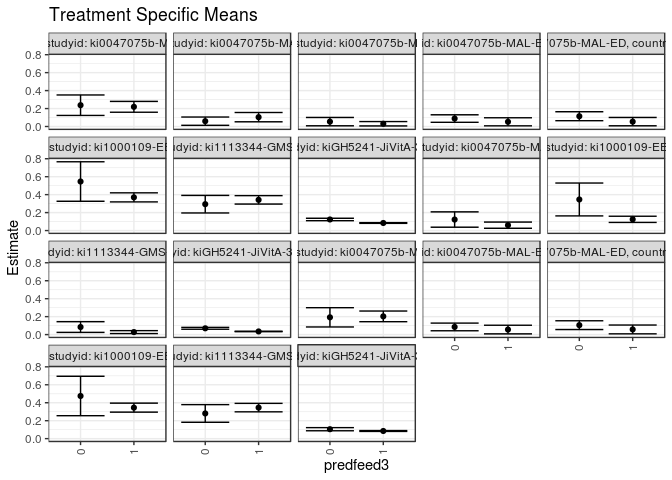

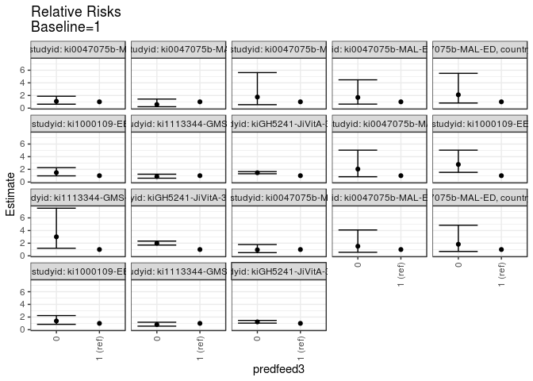

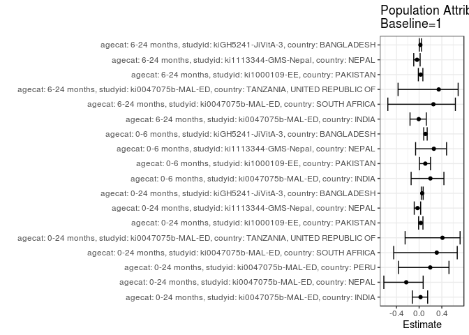

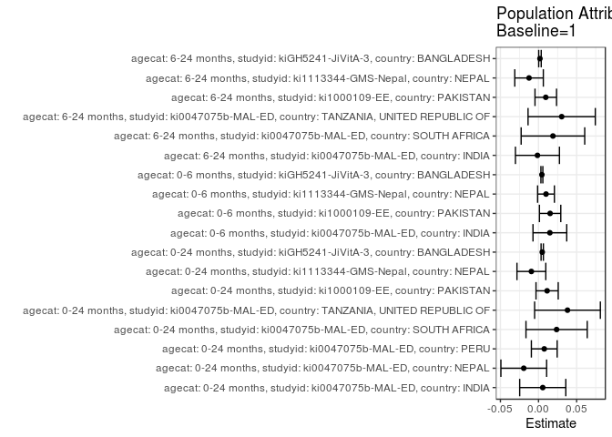

## Results Table

### Parameter: TSM

| agecat | studyid | country | intervention_level | baseline_level | estimate | ci_lower | ci_upper |
| --- | --- | --- | --- | --- | --- | --- | --- |
| 0-24 months | ki0047075b-MAL-ED | INDIA | 1 | NA | 0.2194374 | 0.1591776 | 0.2796972 |
| 0-24 months | ki0047075b-MAL-ED | INDIA | 0 | NA | 0.2376723 | 0.1236491 | 0.3516955 |
| 0-24 months | ki0047075b-MAL-ED | NEPAL | 1 | NA | 0.1044776 | 0.0525771 | 0.1563781 |
| 0-24 months | ki0047075b-MAL-ED | NEPAL | 0 | NA | 0.0594059 | 0.0132073 | 0.1056046 |
| 0-24 months | ki0047075b-MAL-ED | PERU | 1 | NA | 0.0309278 | 0.0065239 | 0.0553318 |
| 0-24 months | ki0047075b-MAL-ED | PERU | 0 | NA | 0.0543478 | 0.0079421 | 0.1007536 |
| 0-24 months | ki0047075b-MAL-ED | SOUTH AFRICA | 1 | NA | 0.0526316 | 0.0076474 | 0.0976158 |
| 0-24 months | ki0047075b-MAL-ED | SOUTH AFRICA | 0 | NA | 0.0888889 | 0.0472391 | 0.1305386 |
| 0-24 months | ki0047075b-MAL-ED | TANZANIA, UNITED REPUBLIC OF | 1 | NA | 0.0543478 | 0.0079300 | 0.1007657 |
| 0-24 months | ki0047075b-MAL-ED | TANZANIA, UNITED REPUBLIC OF | 0 | NA | 0.1146497 | 0.0647134 | 0.1645860 |
| 0-24 months | ki1000109-EE | PAKISTAN | 1 | NA | 0.3696734 | 0.3190208 | 0.4203260 |
| 0-24 months | ki1000109-EE | PAKISTAN | 0 | NA | 0.5462958 | 0.3261872 | 0.7664044 |
| 0-24 months | ki1113344-GMS-Nepal | NEPAL | 1 | NA | 0.3419852 | 0.2950748 | 0.3888955 |
| 0-24 months | ki1113344-GMS-Nepal | NEPAL | 0 | NA | 0.2938592 | 0.1960981 | 0.3916204 |
| 0-24 months | kiGH5241-JiVitA-3 | BANGLADESH | 1 | NA | 0.0844616 | 0.0804500 | 0.0884732 |
| 0-24 months | kiGH5241-JiVitA-3 | BANGLADESH | 0 | NA | 0.1234148 | 0.1100011 | 0.1368285 |
| 0-6 months | ki0047075b-MAL-ED | INDIA | 1 | NA | 0.0601093 | 0.0255998 | 0.0946188 |
| 0-6 months | ki0047075b-MAL-ED | INDIA | 0 | NA | 0.1228070 | 0.0374230 | 0.2081910 |
| 0-6 months | ki1000109-EE | PAKISTAN | 1 | NA | 0.1250000 | 0.0904052 | 0.1595948 |
| 0-6 months | ki1000109-EE | PAKISTAN | 0 | NA | 0.3461538 | 0.1630451 | 0.5292626 |
| 0-6 months | ki1113344-GMS-Nepal | NEPAL | 1 | NA | 0.0280612 | 0.0116955 | 0.0444270 |
| 0-6 months | ki1113344-GMS-Nepal | NEPAL | 0 | NA | 0.0843373 | 0.0244901 | 0.1441846 |
| 0-6 months | kiGH5241-JiVitA-3 | BANGLADESH | 1 | NA | 0.0351222 | 0.0326474 | 0.0375970 |
| 0-6 months | kiGH5241-JiVitA-3 | BANGLADESH | 0 | NA | 0.0700275 | 0.0595943 | 0.0804606 |
| 6-24 months | ki0047075b-MAL-ED | INDIA | 1 | NA | 0.2031255 | 0.1435866 | 0.2626643 |
| 6-24 months | ki0047075b-MAL-ED | INDIA | 0 | NA | 0.1924754 | 0.0850929 | 0.2998579 |
| 6-24 months | ki0047075b-MAL-ED | SOUTH AFRICA | 1 | NA | 0.0561798 | 0.0082453 | 0.1041142 |
| 6-24 months | ki0047075b-MAL-ED | SOUTH AFRICA | 0 | NA | 0.0853659 | 0.0425157 | 0.1282160 |
| 6-24 months | ki0047075b-MAL-ED | TANZANIA, UNITED REPUBLIC OF | 1 | NA | 0.0574713 | 0.0084627 | 0.1064798 |
| 6-24 months | ki0047075b-MAL-ED | TANZANIA, UNITED REPUBLIC OF | 0 | NA | 0.1052632 | 0.0563729 | 0.1541534 |
| 6-24 months | ki1000109-EE | PAKISTAN | 1 | NA | 0.3453230 | 0.2951954 | 0.3954505 |
| 6-24 months | ki1000109-EE | PAKISTAN | 0 | NA | 0.4751289 | 0.2556574 | 0.6946004 |
| 6-24 months | ki1113344-GMS-Nepal | NEPAL | 1 | NA | 0.3457463 | 0.2984039 | 0.3930887 |
| 6-24 months | ki1113344-GMS-Nepal | NEPAL | 0 | NA | 0.2805655 | 0.1824117 | 0.3787193 |
| 6-24 months | kiGH5241-JiVitA-3 | BANGLADESH | 1 | NA | 0.0851869 | 0.0803289 | 0.0900449 |
| 6-24 months | kiGH5241-JiVitA-3 | BANGLADESH | 0 | NA | 0.1050214 | 0.0875638 | 0.1224790 |

### Parameter: E(Y)

| agecat | studyid | country | intervention_level | baseline_level | estimate | ci_lower | ci_upper |
| --- | --- | --- | --- | --- | --- | --- | --- |
| 0-24 months | ki0047075b-MAL-ED | INDIA | NA | NA | 0.2250000 | 0.1720591 | 0.2779409 |
| 0-24 months | ki0047075b-MAL-ED | NEPAL | NA | NA | 0.0851064 | 0.0493539 | 0.1208589 |
| 0-24 months | ki0047075b-MAL-ED | PERU | NA | NA | 0.0384615 | 0.0161350 | 0.0607881 |
| 0-24 months | ki0047075b-MAL-ED | SOUTH AFRICA | NA | NA | 0.0763636 | 0.0449175 | 0.1078097 |
| 0-24 months | ki0047075b-MAL-ED | TANZANIA, UNITED REPUBLIC OF | NA | NA | 0.0923695 | 0.0563331 | 0.1284058 |
| 0-24 months | ki1000109-EE | PAKISTAN | NA | NA | 0.3809524 | 0.3319322 | 0.4299725 |
| 0-24 months | ki1113344-GMS-Nepal | NEPAL | NA | NA | 0.3326316 | 0.2902162 | 0.3750470 |
| 0-24 months | kiGH5241-JiVitA-3 | BANGLADESH | NA | NA | 0.0893460 | 0.0853745 | 0.0933175 |
| 0-6 months | ki0047075b-MAL-ED | INDIA | NA | NA | 0.0750000 | 0.0416074 | 0.1083926 |
| 0-6 months | ki1000109-EE | PAKISTAN | NA | NA | 0.1402116 | 0.1051635 | 0.1752598 |
| 0-6 months | ki1113344-GMS-Nepal | NEPAL | NA | NA | 0.0378947 | 0.0207054 | 0.0550841 |
| 0-6 months | kiGH5241-JiVitA-3 | BANGLADESH | NA | NA | 0.0395463 | 0.0370065 | 0.0420860 |
| 6-24 months | ki0047075b-MAL-ED | INDIA | NA | NA | 0.2017167 | 0.1500806 | 0.2533529 |
| 6-24 months | ki0047075b-MAL-ED | SOUTH AFRICA | NA | NA | 0.0750988 | 0.0425592 | 0.1076384 |
| 6-24 months | ki0047075b-MAL-ED | TANZANIA, UNITED REPUBLIC OF | NA | NA | 0.0878661 | 0.0518995 | 0.1238327 |
| 6-24 months | ki1000109-EE | PAKISTAN | NA | NA | 0.3548387 | 0.3061520 | 0.4035255 |
| 6-24 months | ki1113344-GMS-Nepal | NEPAL | NA | NA | 0.3333333 | 0.2905787 | 0.3760880 |
| 6-24 months | kiGH5241-JiVitA-3 | BANGLADESH | NA | NA | 0.0870892 | 0.0823628 | 0.0918157 |

### Parameter: RR

| agecat | studyid | country | intervention_level | baseline_level | estimate | ci_lower | ci_upper |
| --- | --- | --- | --- | --- | --- | --- | --- |
| 0-24 months | ki0047075b-MAL-ED | INDIA | 1 | 1 | 1.0000000 | 1.0000000 | 1.000000 |
| 0-24 months | ki0047075b-MAL-ED | INDIA | 0 | 1 | 1.0830987 | 0.6232371 | 1.882274 |
| 0-24 months | ki0047075b-MAL-ED | NEPAL | 1 | 1 | 1.0000000 | 1.0000000 | 1.000000 |
| 0-24 months | ki0047075b-MAL-ED | NEPAL | 0 | 1 | 0.5685997 | 0.2259648 | 1.430778 |
| 0-24 months | ki0047075b-MAL-ED | PERU | 1 | 1 | 1.0000000 | 1.0000000 | 1.000000 |
| 0-24 months | ki0047075b-MAL-ED | PERU | 0 | 1 | 1.7572464 | 0.5494264 | 5.620252 |
| 0-24 months | ki0047075b-MAL-ED | SOUTH AFRICA | 1 | 1 | 1.0000000 | 1.0000000 | 1.000000 |
| 0-24 months | ki0047075b-MAL-ED | SOUTH AFRICA | 0 | 1 | 1.6888889 | 0.6372207 | 4.476229 |
| 0-24 months | ki0047075b-MAL-ED | TANZANIA, UNITED REPUBLIC OF | 1 | 1 | 1.0000000 | 1.0000000 | 1.000000 |
| 0-24 months | ki0047075b-MAL-ED | TANZANIA, UNITED REPUBLIC OF | 0 | 1 | 2.1095541 | 0.8087549 | 5.502555 |
| 0-24 months | ki1000109-EE | PAKISTAN | 1 | 1 | 1.0000000 | 1.0000000 | 1.000000 |
| 0-24 months | ki1000109-EE | PAKISTAN | 0 | 1 | 1.4777797 | 0.9652987 | 2.262339 |
| 0-24 months | ki1113344-GMS-Nepal | NEPAL | 1 | 1 | 1.0000000 | 1.0000000 | 1.000000 |
| 0-24 months | ki1113344-GMS-Nepal | NEPAL | 0 | 1 | 0.8592747 | 0.6002896 | 1.229995 |
| 0-24 months | kiGH5241-JiVitA-3 | BANGLADESH | 1 | 1 | 1.0000000 | 1.0000000 | 1.000000 |
| 0-24 months | kiGH5241-JiVitA-3 | BANGLADESH | 0 | 1 | 1.4611940 | 1.3046994 | 1.636460 |
| 0-6 months | ki0047075b-MAL-ED | INDIA | 1 | 1 | 1.0000000 | 1.0000000 | 1.000000 |
| 0-6 months | ki0047075b-MAL-ED | INDIA | 0 | 1 | 2.0430622 | 0.8292627 | 5.033511 |
| 0-6 months | ki1000109-EE | PAKISTAN | 1 | 1 | 1.0000000 | 1.0000000 | 1.000000 |
| 0-6 months | ki1000109-EE | PAKISTAN | 0 | 1 | 2.7692308 | 1.5243435 | 5.030781 |
| 0-6 months | ki1113344-GMS-Nepal | NEPAL | 1 | 1 | 1.0000000 | 1.0000000 | 1.000000 |
| 0-6 months | ki1113344-GMS-Nepal | NEPAL | 0 | 1 | 3.0054765 | 1.1995016 | 7.530535 |
| 0-6 months | kiGH5241-JiVitA-3 | BANGLADESH | 1 | 1 | 1.0000000 | 1.0000000 | 1.000000 |
| 0-6 months | kiGH5241-JiVitA-3 | BANGLADESH | 0 | 1 | 1.9938227 | 1.7052843 | 2.331183 |
| 6-24 months | ki0047075b-MAL-ED | INDIA | 1 | 1 | 1.0000000 | 1.0000000 | 1.000000 |
| 6-24 months | ki0047075b-MAL-ED | INDIA | 0 | 1 | 0.9475691 | 0.5040148 | 1.781470 |
| 6-24 months | ki0047075b-MAL-ED | SOUTH AFRICA | 1 | 1 | 1.0000000 | 1.0000000 | 1.000000 |
| 6-24 months | ki0047075b-MAL-ED | SOUTH AFRICA | 0 | 1 | 1.5195122 | 0.5646526 | 4.089093 |
| 6-24 months | ki0047075b-MAL-ED | TANZANIA, UNITED REPUBLIC OF | 1 | 1 | 1.0000000 | 1.0000000 | 1.000000 |
| 6-24 months | ki0047075b-MAL-ED | TANZANIA, UNITED REPUBLIC OF | 0 | 1 | 1.8315789 | 0.6936052 | 4.836586 |
| 6-24 months | ki1000109-EE | PAKISTAN | 1 | 1 | 1.0000000 | 1.0000000 | 1.000000 |
| 6-24 months | ki1000109-EE | PAKISTAN | 0 | 1 | 1.3758970 | 0.8476068 | 2.233456 |
| 6-24 months | ki1113344-GMS-Nepal | NEPAL | 1 | 1 | 1.0000000 | 1.0000000 | 1.000000 |
| 6-24 months | ki1113344-GMS-Nepal | NEPAL | 0 | 1 | 0.8114778 | 0.5576739 | 1.180791 |
| 6-24 months | kiGH5241-JiVitA-3 | BANGLADESH | 1 | 1 | 1.0000000 | 1.0000000 | 1.000000 |
| 6-24 months | kiGH5241-JiVitA-3 | BANGLADESH | 0 | 1 | 1.2328348 | 1.0374267 | 1.465050 |

### Parameter: PAR

| agecat | studyid | country | intervention_level | baseline_level | estimate | ci_lower | ci_upper |
| --- | --- | --- | --- | --- | --- | --- | --- |
| 0-24 months | ki0047075b-MAL-ED | INDIA | 1 | NA | 0.0055626 | -0.0246956 | 0.0358209 |
| 0-24 months | ki0047075b-MAL-ED | NEPAL | 1 | NA | -0.0193712 | -0.0493709 | 0.0106285 |
| 0-24 months | ki0047075b-MAL-ED | PERU | 1 | NA | 0.0075337 | -0.0093801 | 0.0244475 |
| 0-24 months | ki0047075b-MAL-ED | SOUTH AFRICA | 1 | NA | 0.0237321 | -0.0164466 | 0.0639107 |
| 0-24 months | ki0047075b-MAL-ED | TANZANIA, UNITED REPUBLIC OF | 1 | NA | 0.0380217 | -0.0051185 | 0.0811618 |
| 0-24 months | ki1000109-EE | PAKISTAN | 1 | NA | 0.0112790 | -0.0032932 | 0.0258512 |
| 0-24 months | ki1113344-GMS-Nepal | NEPAL | 1 | NA | -0.0093536 | -0.0282635 | 0.0095564 |
| 0-24 months | kiGH5241-JiVitA-3 | BANGLADESH | 1 | NA | 0.0048844 | 0.0033751 | 0.0063937 |
| 0-6 months | ki0047075b-MAL-ED | INDIA | 1 | NA | 0.0148907 | -0.0072417 | 0.0370231 |
| 0-6 months | ki1000109-EE | PAKISTAN | 1 | NA | 0.0152116 | 0.0012041 | 0.0292192 |
| 0-6 months | ki1113344-GMS-Nepal | NEPAL | 1 | NA | 0.0098335 | -0.0011773 | 0.0208444 |
| 0-6 months | kiGH5241-JiVitA-3 | BANGLADESH | 1 | NA | 0.0044241 | 0.0031714 | 0.0056768 |
| 6-24 months | ki0047075b-MAL-ED | INDIA | 1 | NA | -0.0014087 | -0.0302843 | 0.0274668 |
| 6-24 months | ki0047075b-MAL-ED | SOUTH AFRICA | 1 | NA | 0.0189190 | -0.0227938 | 0.0606319 |
| 6-24 months | ki0047075b-MAL-ED | TANZANIA, UNITED REPUBLIC OF | 1 | NA | 0.0303948 | -0.0137279 | 0.0745176 |
| 6-24 months | ki1000109-EE | PAKISTAN | 1 | NA | 0.0095157 | -0.0046217 | 0.0236531 |
| 6-24 months | ki1113344-GMS-Nepal | NEPAL | 1 | NA | -0.0124130 | -0.0311435 | 0.0063175 |
| 6-24 months | kiGH5241-JiVitA-3 | BANGLADESH | 1 | NA | 0.0019023 | 0.0002543 | 0.0035504 |

### Parameter: PAF

| agecat | studyid | country | intervention_level | baseline_level | estimate | ci_lower | ci_upper |
| --- | --- | --- | --- | --- | --- | --- | --- |
| 0-24 months | ki0047075b-MAL-ED | INDIA | 1 | NA | 0.0247228 | -0.1194344 | 0.1503158 |
| 0-24 months | ki0047075b-MAL-ED | NEPAL | 1 | NA | -0.2276119 | -0.6224551 | 0.0711416 |
| 0-24 months | ki0047075b-MAL-ED | PERU | 1 | NA | 0.1958763 | -0.3654664 | 0.5264512 |
| 0-24 months | ki0047075b-MAL-ED | SOUTH AFRICA | 1 | NA | 0.3107769 | -0.4490773 | 0.6721856 |
| 0-24 months | ki0047075b-MAL-ED | TANZANIA, UNITED REPUBLIC OF | 1 | NA | 0.4116257 | -0.2472577 | 0.7224436 |
| 0-24 months | ki1000109-EE | PAKISTAN | 1 | NA | 0.0296074 | -0.0094682 | 0.0671704 |
| 0-24 months | ki1113344-GMS-Nepal | NEPAL | 1 | NA | -0.0281199 | -0.0865863 | 0.0272005 |
| 0-24 months | kiGH5241-JiVitA-3 | BANGLADESH | 1 | NA | 0.0546683 | 0.0378517 | 0.0711910 |
| 0-6 months | ki0047075b-MAL-ED | INDIA | 1 | NA | 0.1985428 | -0.1413521 | 0.4372169 |
| 0-6 months | ki1000109-EE | PAKISTAN | 1 | NA | 0.1084906 | 0.0057298 | 0.2006307 |
| 0-6 months | ki1113344-GMS-Nepal | NEPAL | 1 | NA | 0.2594955 | -0.0622319 | 0.4837785 |
| 0-6 months | kiGH5241-JiVitA-3 | BANGLADESH | 1 | NA | 0.1118705 | 0.0810238 | 0.1416818 |
| 6-24 months | ki0047075b-MAL-ED | INDIA | 1 | NA | -0.0069837 | -0.1607893 | 0.1264425 |
| 6-24 months | ki0047075b-MAL-ED | SOUTH AFRICA | 1 | NA | 0.2519219 | -0.5519882 | 0.6394169 |
| 6-24 months | ki0047075b-MAL-ED | TANZANIA, UNITED REPUBLIC OF | 1 | NA | 0.3459223 | -0.3716996 | 0.6881113 |
| 6-24 months | ki1000109-EE | PAKISTAN | 1 | NA | 0.0268170 | -0.0138684 | 0.0658698 |
| 6-24 months | ki1113344-GMS-Nepal | NEPAL | 1 | NA | -0.0372389 | -0.0949979 | 0.0174734 |
| 6-24 months | kiGH5241-JiVitA-3 | BANGLADESH | 1 | NA | 0.0218436 | 0.0028111 | 0.0405129 |